# Elias 3o4p ASP 229_0_0.1_8

## 3d view of density

xyz

yzx

zxy

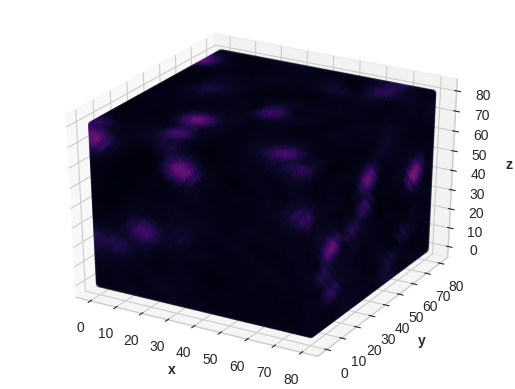

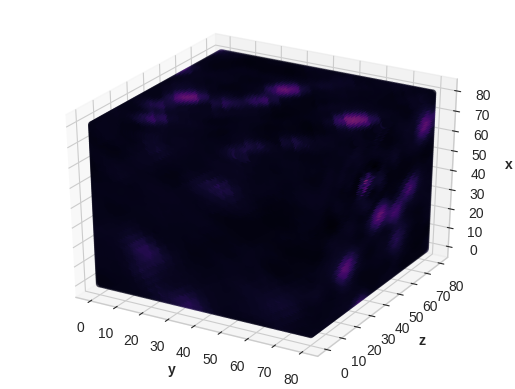

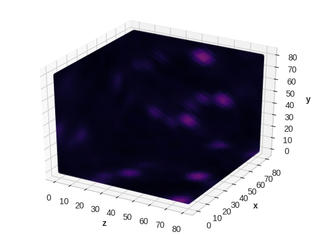

## Slices along x,y and z

Sliced x-wise

Sliced y-wise

Sliced z-wise

0/81

0/81

0/81

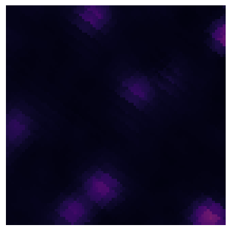

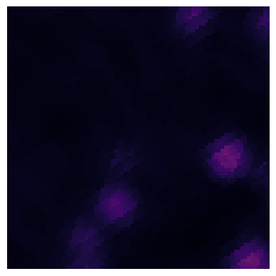

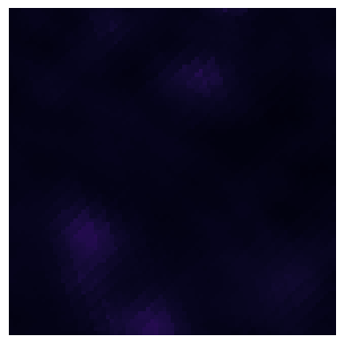

1/81

1/81

1/81

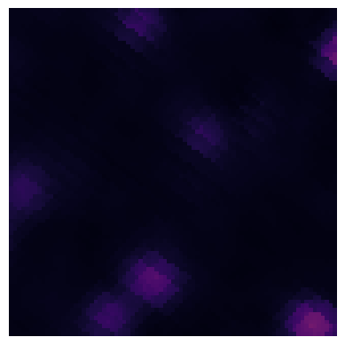

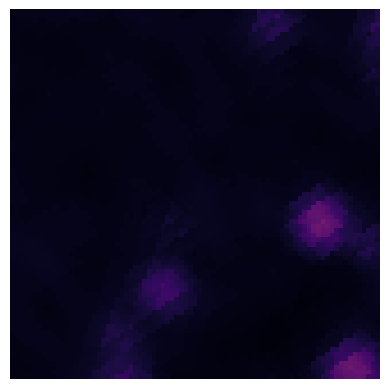

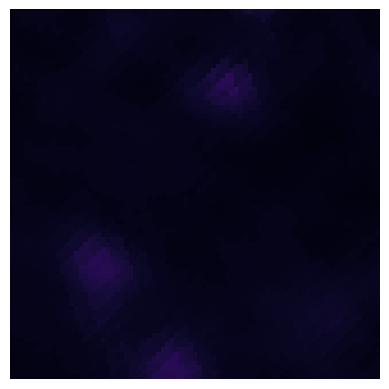

2/81

2/81

2/81

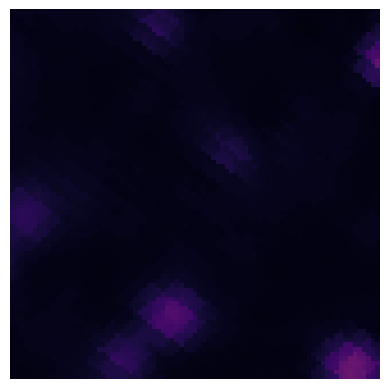

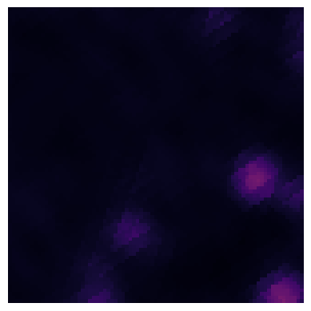

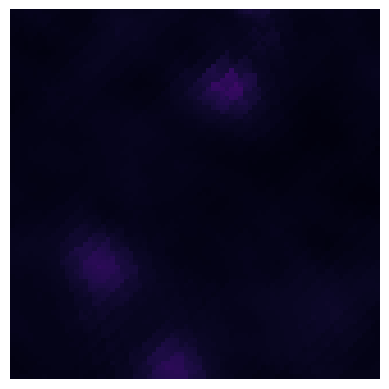

3/81

3/81

3/81

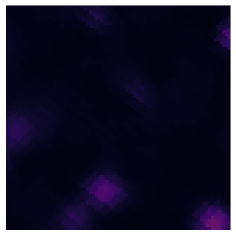

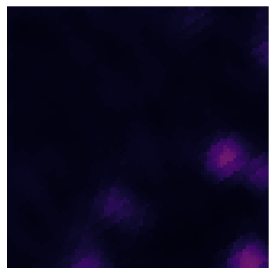

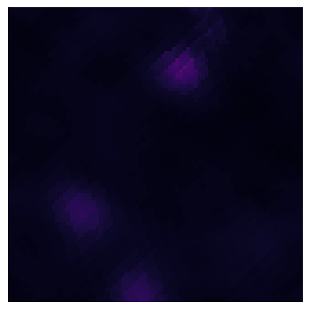

4/81

4/81

4/81

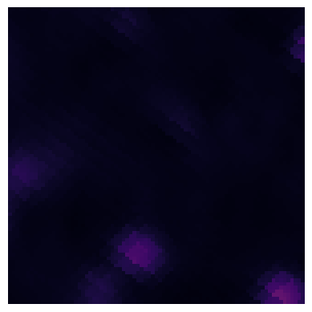

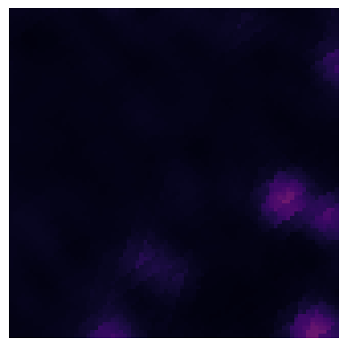

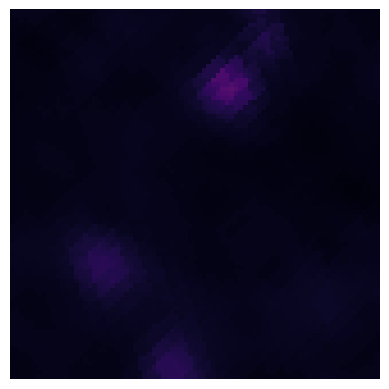

5/81

5/81

5/81

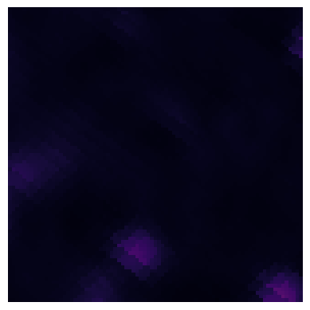

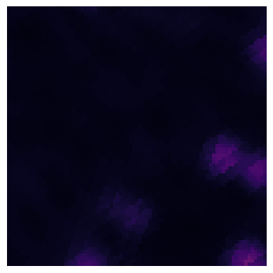

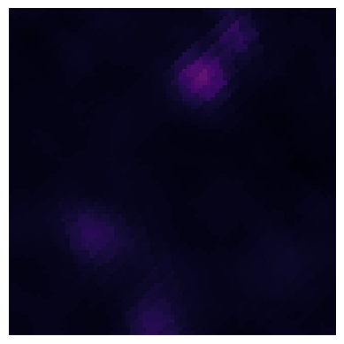

6/81

6/81

6/81

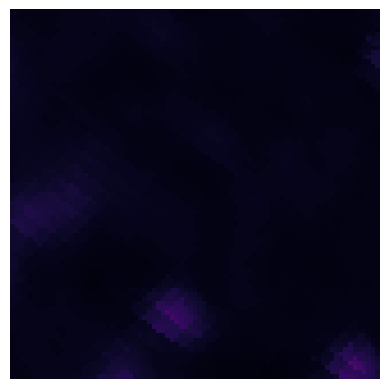

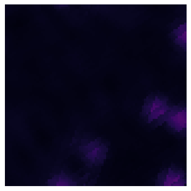

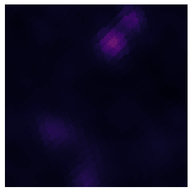

7/81

7/81

7/81

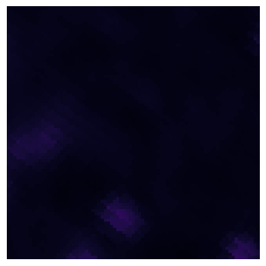

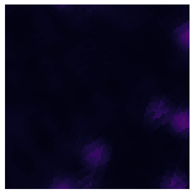

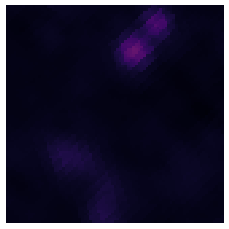

8/81

8/81

8/81

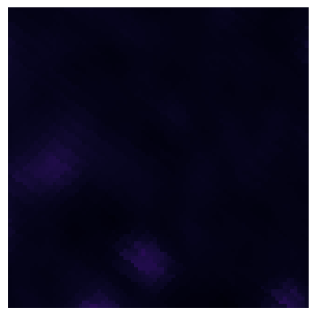

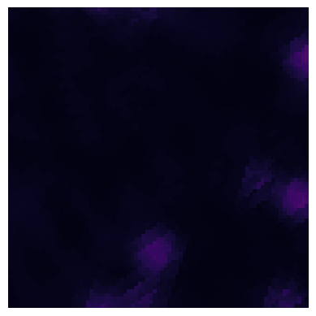

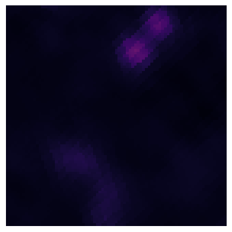

9/81

9/81

9/81

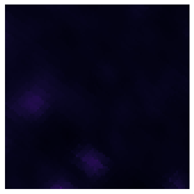

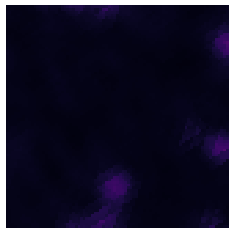

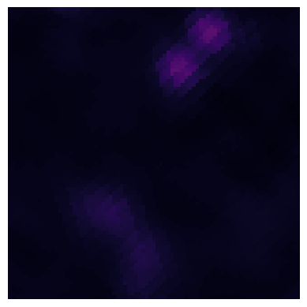

10/81

10/81